# Practical Machine Learning Course Project

Venkata Yerubandi

May 23, 2015

### Background

Using devices such as Jawbone Up, Nike FuelBand, and Fitbit it is now possible to collect a large amount of data about personal activity relatively inexpensively. These type of devices are part of the quantified self movement – a group of enthusiasts who take measurements about themselves regularly to improve their health, to find patterns in their behavior, or because they are tech geeks. One thing that people regularly do is quantify how much of a particular activity they do, but they rarely quantify how well they do it. In this project, your goal will be to use data from accelerometers on the belt, forearm, arm, and dumbell of 6 participants. They were asked to perform barbell lifts correctly and incorrectly in 5 different ways. More information is available from the website [here:](http://groupware.les.inf.puc-rio.br/har) (see the section on the Weight Lifting Exercise Dataset).

### Data

The training data for this project are available here: [train data](https://d396qusza40orc.cloudfront.net/predmachlearn/pml-training.csv)

The test data are available here: [test data](https://d396qusza40orc.cloudfront.net/predmachlearn/pml-testing.csv)

The data for this project come from this source: http://groupware.les.inf.puc-rio.br/har. If you use the document you create for this class for any purpose please cite them as they have been very generous in allowing their data to be used for this kind of assignment.

### Goal

The goal of this project is to predict the manner in which the subjects did the exercise. This is the “classe” variable in the training set. In accomplishing the above we create a report describing how we built the model, used cross validation, what you think the expected out of sample error is, and why we made the choices we did. Finally using the model we have, we prediction the outcomes for 20 different test cases.

### Preliminary Work

#### Package Installation

We need to install the following packages : randomForest, rattle, rpart etc

#### Reproducability

To ensure the reproducability of the data analysis , we use a special seed 5555.

#### Building the model

Outcome variable is **classe**. It is a factor variable with the following specification

- perfect posture as per specification (Class A)
- throwing the elbows to the front (Class B),
- lifting the dumbbell only halfway (Class C),
- lowering the dumbbell only halfway (Class D)
- throwing the hips to the front (Class E).

After cleaning the data, we will try to fit a model and use it for predictions. We will experiment with various models and select the one with highest accuracy.

#### Cross Validation

We use cross validation to compare the performances of different predictive modelling procedures. We use random sub sampling validation with out replacement. We accomplish this by bifurcating the training data into subSampleTraining data (80% of the original Training data set) and subSampleTesting data (20%). We essentially try to figure out the accurate model using the subSample data sets and test it on the original Testing data set.

#### Expected out of sample error

We calculate this quantity using 1-accuracy. Accuracy is number of correctly classified items over total number of items in the data set. This measure is used to select the accurate model in the cross validated data set.

#### Data Analysis

```r
# set the seed for reproducability
set.seed(5555)

# loading the required libraries
library(caret)
library(randomForest)
```

```r
library(rpart)
library(rpart.plot)
```

##### Cleaning Data

On a precursory walk through of the csv files , we see that the file needs some data cleaning - like remove NA,#DIV/0! etc

```r
# Load the training data set
trainingset <- read.csv("/Users/venkata/Downloads/coursera/Practical Machine Learning/Project/pml-training.csv", na.strings=c("NA","#DIV/0!", ""))

# Load the testing data set
testingset <- read.csv("/Users/venkata/Downloads/coursera/Practical Machine Learning/Project/pml-testing.csv", na.strings=c("NA","#DIV/0!", ""))

# Check dimensions for number of variables and number of observations
dim(trainingset)
```

```
## [1] 19622   160
```

```r
dim(testingset)
```

```
## [1]  20 160
```

```r
# Delete columns with all missing values
trainingset<-trainingset[,colSums(is.na(trainingset)) == 0]
testingset <-testingset[,colSums(is.na(testingset)) == 0]

# Deleting the irrelavent variables
trainingset   <-trainingset[,-c(1:7)]
testingset <-testingset[,-c(1:7)]

# Check dimensions for number of variables and number of observations after the clean up
dim(trainingset)
```

```
## [1] 19622    53
```

```r
dim(testingset)
```

```
## [1] 20 53
```

```r
# for debugging
#head(trainingset)
#head(testingset)
```

##### Cross Validation on partitioned training data sets

We further create subSampleTraining and subSampleTesting data sets using the 80%/20% ratio

```r
subsamples <- createDataPartition(y=trainingset$classe, p=0.80, list=FALSE)
subSampleTraining <- trainingset[subsamples, ]
subSampleTesting <- trainingset[-subsamples, ]
```

##### 1. Trying out modelling using decision tree

We try to fit a decision tree on the subSampleTraining data set

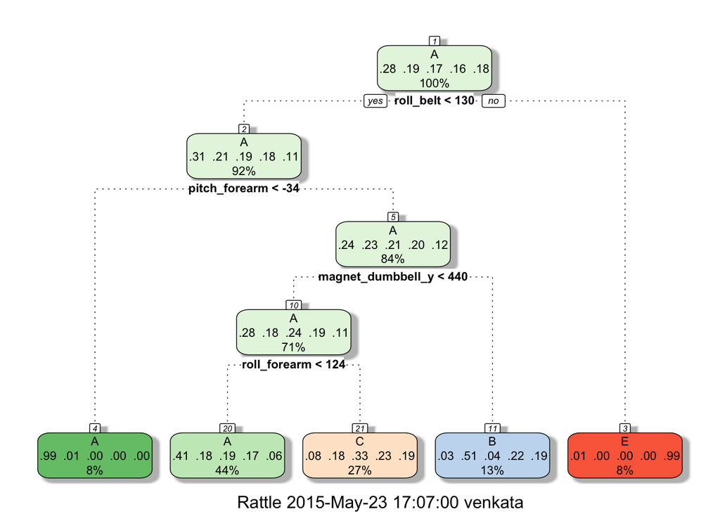

```r
# preparing model1
ctrl <- trainControl(allowParallel=TRUE)
fit1 <- train(classe ~.,data=subSampleTraining,method="rpart" , trControl = ctrl)

# prediction
prediction1 <- predict(fit1,subSampleTesting)
#prediction1

# plotting
library(rattle)
fancyRpartPlot(fit1$finalModel)
```

##### Confusion matrix for model built using decision tree

We calculate a cross-tabulation of observed and predicted classes with associated statistics.

```r
confusionMatrix(prediction1, subSampleTesting$classe)
```

```
## Confusion Matrix and Statistics
##
##           Reference
## Prediction    A    B    C    D    E
##          A 1005  344  300  291   98
##          B   15  238   23  113  103
##          C   92  177  361  239  190
##          D    0    0    0    0    0
##          E    4    0    0    0  330
##
## Overall Statistics
##
##                Accuracy : 0.493
##                  95% CI : (0.4772, 0.5088)
##     No Information Rate : 0.2845
##     P-Value [Acc > NIR] : < 2.2e-16
##
##                   Kappa : 0.3374
##  Mcnemar's Test P-Value : NA
##
## Statistics by Class:
##
##                      Class: A Class: B Class: C Class: D Class: E
## Sensitivity            0.9005  0.31357  0.52778   0.0000  0.45770
## Specificity            0.6320  0.91972  0.78450   1.0000  0.99875
## Pos Pred Value         0.4931  0.48374  0.34089      NaN  0.98802
## Neg Pred Value         0.9411  0.84815  0.88722   0.8361  0.89106
## Prevalence             0.2845  0.19347  0.17436   0.1639  0.18379
## Detection Rate         0.2562  0.06067  0.09202   0.0000  0.08412
## Detection Prevalence   0.5195  0.12541  0.26995   0.0000  0.08514
## Balanced Accuracy      0.7663  0.61665  0.65614   0.5000  0.72822
```

##### 2. Trying out modelling using random forests

We try to fit a random forest on the subSampleTraining data set

```r
# preparing model1
fit2 <- randomForest(classe ~.,data=subSampleTraining,method="class" )

# prediction
prediction2 <- predict(fit2,subSampleTesting,type="class")
```

##### Confusion matrix for model built using random trees

We calculate a cross-tabulation of observed and predicted classes with associated statistics.

```r
confusionMatrix(prediction2, subSampleTesting$classe)
```

```
## Confusion Matrix and Statistics
##
##           Reference
## Prediction    A    B    C    D    E
##          A 1115    3    0    0    0
##          B    1  756    2    0    0
##          C    0    0  681    5    0
##          D    0    0    1  637    1
##          E    0    0    0    1  720
##
## Overall Statistics
##
##                Accuracy : 0.9964
##                  95% CI : (0.994, 0.998)
##     No Information Rate : 0.2845
##     P-Value [Acc > NIR] : < 2.2e-16
##
##                   Kappa : 0.9955
##  Mcnemar's Test P-Value : NA
##
## Statistics by Class:
##
##                      Class: A Class: B Class: C Class: D Class: E
## Sensitivity            0.9991   0.9960   0.9956   0.9907   0.9986
## Specificity            0.9989   0.9991   0.9985   0.9994   0.9997
## Pos Pred Value         0.9973   0.9960   0.9927   0.9969   0.9986
## Neg Pred Value         0.9996   0.9991   0.9991   0.9982   0.9997
## Prevalence             0.2845   0.1935   0.1744   0.1639   0.1838
## Detection Rate         0.2842   0.1927   0.1736   0.1624   0.1835
## Detection Prevalence   0.2850   0.1935   0.1749   0.1629   0.1838
## Balanced Accuracy      0.9990   0.9975   0.9970   0.9950   0.9992
```

#### Outcome

##### Differences between decision trees and random forests

From Wikipedia - In particular, trees that are grown very deep tend to learn highly irregular patterns: they overfit their training sets, because they have low bias, but very high variance. Random forests are a way of averaging multiple deep decision trees, trained on different parts of the same training set, with the goal of reducing the variance. This comes at the expense of a small increase in the bias and some loss of interpretability, but generally greatly boosts the performance of the final model.

**So ideally Random Forests should do better than decision trees.**

This is supported in our thesis as well - Accuracy for Random Forest model was 0.996 (95% CI: (0.994, 0.998)) compared to 0.493 (95% CI: (0.4772, 0.5088)) for Decision Tree model. So we choose random Forest model. The accuracy of the model is 0.996. The expected out-of-sample error is estimated at 0.004, or 0.4%.

The expected out-of-sample error is calculated as 1 - accuracy for predictions made against the cross-validation set. Our Test data set comprises 20 cases. With an accuracy above 99% on our cross-validation data, we can expect that very few, or none, of the test samples will be missclassified.

##### Prediction on test data

```r
finalprediction <- predict(fit2, testingset, type="class")
finalprediction
```

```
##  1  2  3  4  5  6  7  8  9 10 11 12 13 14 15 16 17 18 19 20
##  B  A  B  A  A  E  D  B  A  A  B  C  B  A  E  E  A  B  B  B
## Levels: A B C D E
```

```r
# Write files for submission
pml_write_files = function(x){
  n = length(x)
  for(i in 1:n){
    filename = paste0("problem_id_",i,".txt")
    write.table(x[i],file=filename,quote=FALSE,row.names=FALSE,col.names=FALSE)
  }
}

pml_write_files(finalprediction)
```

#### References

- [Cross Validation](http://en.wikipedia.org/wiki/Cross-validation_%28statistics%29)
- [Random Forests](http://en.wikipedia.org/wiki/Random_forest#Preliminaries:_decision_tree_learning)